# 第10回 データを分析する（3）：2群の平均値の比較（t検定の実行と解釈）

行動計量学（行動科学分析法入門）

小野原 彩香

令和8年度

## 本日の目標

1. 独立2標本t検定の論理を理解する
2. Rで `t.test()` を実行し，結果を解釈できる
3. 効果量（Cohenの *d*）を計算・解釈できる
4. **発展**：t統計量と効果量 *d* の式を，自分で導ける

## 準備：パッケージの読み込み

この回のコードは，すべて `tidyverse` を読み込んだ状態で動きます。 RStudioを起動したら，**まずこれを実行してください。**

```r
library(tidyverse)
```

> 毎回必要です。読み込まないまま `filter()` や `ggplot()` を使うと， 「関数が見つかりません」というエラーになります。

## 1. 2群の平均値を比較するとき

### 「差がある」とはどういうことか？

- A組の平均点：75点，B組の平均点：80点
- この5点の差は**偶然のばらつき**か，**本当の差**か？

→ **t検定（独立2標本t検定）** で統計的に判断します

## 2. t検定の仕組み

### 仮説の設定

- **帰無仮説 H₀**：2群の母平均は等しい（μ₁ = μ₂）
- **対立仮説 H₁**：2群の母平均は異なる（μ₁ ≠ μ₂）

### t統計量

$$t = \frac{\bar{x}_1 -
\bar{x}_2}{SE_{差}}$$

- 分子：2群の平均値の差
- 分母：標準誤差（ばらつきの大きさを考慮）

→ t値が大きいほど「差が大きく，偶然とは言いにくい」

**導出①**：分母の $SE_{差}$ は，2つの標準誤差から作られる**

2群の平均値の差 $\bar{x}_1 - \bar{x}_2$ も，標本を取り直すたびに揺れる量です。その揺れの大きさが分母になります。

分散は，**2群が互いに独立なら**和について加法的です。引き算でも符号は効きません（$\mathrm{Var}[-X] = \mathrm{Var}[X]$）。したがって

$$\mathrm{Var}[\bar{X}_1 - \bar{X}_2] =
\mathrm{Var}[\bar{X}_1] + \mathrm{Var}[\bar{X}_2]$$

各群の標本平均の標準誤差は $SE_i = s_i / \sqrt{n_i}$ なので，平方根を取って

$$SE_{差} = \sqrt{SE_1^2 + SE_2^2} =
\sqrt{\frac{s_1^2}{n_1} + \frac{s_2^2}{n_2}}$$

これが $t = \dfrac{\bar{x}_1 - \bar{x}_2}{SE_{差}}$ の分母の正体です。

**数値で確かめる**：mtcars では，オートマ $SE_1 = 0.8796$，マニュアル $SE_2 = 1.7103$ なので

$$SE_{差} = \sqrt{0.8796^2 + 1.7103^2} =
1.9232$$

平均差 $7.2449$ をこれで割ると $7.2449 / 1.9232 = 3.7671$ となり，あとで `t.test()` が返す $t = -3.7671$ の絶対値と一致します（符号は引き算の向きの違いです）。

> **この式は「2群が独立」を使っています。** 同じ人を2回測ったデータ（前後比較など）では2つの測定が独立ではないので，この足し算は成り立ちません。その場合は先に差を取って1標本として扱います（第11回の対応のあるt検定）。

**使った数学**：分散の加法性と，平方根。独立でなければ共分散の項が残ります。

**導出②**：なぜ正規分布ではなく $t$ 分布なのか**

もし母標準偏差 $\sigma$ が分かっていれば，平均の差を $\sigma$ から作った標準誤差で割った量は標準正規分布に従います。分母が定数だからです。

しかし実際には $\sigma$ は分かりません。手元の標本から $s$ を計算して代わりに使います。すると**分母もランダムに揺れる量**になります。

$$t = \frac{\bar{x}_1 -
\bar{x}_2}{\sqrt{s_1^2/n_1 + s_2^2/n_2}}$$

たまたま $s$ が小さめに出た標本では，分子が普通でも比が大きくなります。この「分母のブレ」のぶんだけ，$t$ の分布は正規分布より**裾が重く**なります。標本が小さいほど $s$ が当てにならないので，裾はさらに重くなります。これを表すのが**自由度**です。自由度が大きくなると $t$ 分布は標準正規分布に近づき，$n$ が十分大きければ違いは実用上なくなります。

**数値で確かめる**：mtcars の Welch法では $df = 18.33$ と小数になります。これは2群の分散が異なる場合に自由度を近似的に決めるためです。等分散を仮定する Student法では $df = n_1 + n_2 - 2 = 30$ となり，$t = -4.1061$，$p = 0.000285$ です（Welch法は $t = -3.7671$，$p = 0.001374$）。

**使った数学**：標準化と，未知の母数を推定量で置き換えるという考え方。なお $t$ 分布の密度関数そのものを導くのは，この科目の範囲外です。

## 3. Rで独立2標本t検定を実行する

### 例：オートマ vs. マニュアル車の燃費

```r
# mtcars データ：am（0=オートマ, 1=マニュアル）ごとの燃費(mpg)
mtcars |>
  group_by(am) |>
  summarise(n = n(), mean_mpg = mean(mpg), sd_mpg = sd(mpg))
```

| am | n | mean_mpg | sd_mpg |
| --- | --- | --- | --- |
| 0 | 19 | 17.14737 | 3.833966 |
| 1 | 13 | 24.39231 | 6.166504 |

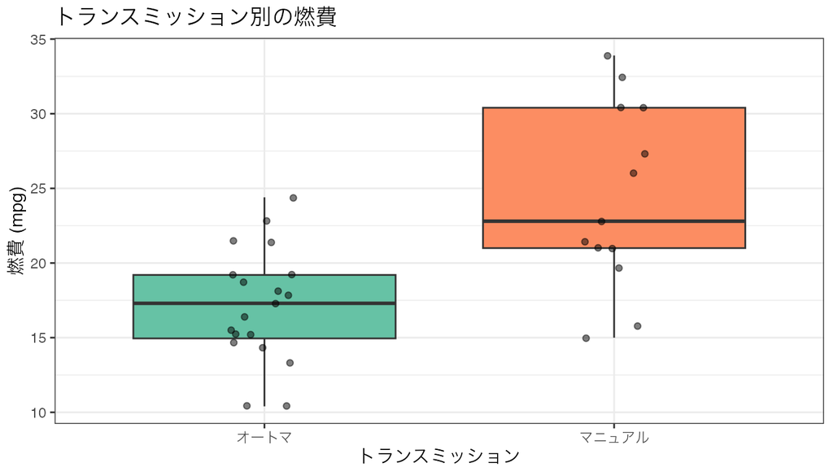

```r
# 箱ひげ図で確認
mtcars |>
  mutate(am = factor(am, labels = c("オートマ", "マニュアル"))) |>
  ggplot(aes(x = am, y = mpg, fill = am)) +
  geom_boxplot() +
  geom_jitter(width = 0.1, alpha = 0.5) +
  scale_fill_brewer(palette = "Set2") +
  labs(title = "トランスミッション別の燃費", x = "トランスミッション", y = "燃費 (mpg)") +
  theme_bw() +
  theme(legend.position = "none")
```

```r
# t検定の実行
t.test(mpg ~ am, data = mtcars)
```

```
##
##  Welch Two Sample t-test
##
## data:  mpg by am
## t = -3.7671, df = 18.332, p-value = 0.001374
## alternative hypothesis: true difference in means between group 0 and group 1 is not equal to 0
## 95 percent confidence interval:
##  -11.280194  -3.209684
## sample estimates:
## mean in group 0 mean in group 1
##        17.14737        24.39231
```

> **`mpg ~ am` という書き方（チルダ記法）** `~` の**左に「比べたい数値」**，**右に「グループを表す列」**を書きます。 「`am` で分けたときの `mpg`」という意味です。 第9回の `xtabs(Freq ~ Sex + Survived, ...)` や，第13回の分散分析 `aov(...)` でも同じ形を使います。 **Rで「何を何で説明するか」を書くときの共通の書式**だと覚えてください。

> **出力の1行目が `Welch Two Sample t-test` になっていることに注目。** `t.test()` は何も指定しないと**Welch法**で計算します（§4で扱います）。

### 結果の読み方

```
    Welch Two Sample t-test

data:  mpg by am
t = -3.7671, df = 18.332, p-value = 0.001374
alternative hypothesis: true difference in means between group 0 and group 1 is not equal to 0
95 percent confidence interval:
 -11.280194  -3.209684
sample estimates:
mean in group 0 mean in group 1
       17.14737        24.39231
```

| 項目 | 意味 |
| --- | --- |
| `t` | t統計量（負の値 = group0 < group1） |
| `df` | 自由度 |
| `p-value` | p値（< 0.05 で有意） |
| `95% CI` | 平均差の95%信頼区間（0を含まなければ有意） |
| `mean in group 0/1` | 各群の平均値 |

## 4. 等分散性の検定

Welch法（分散が等しくない場合に対応）とStudent法（等分散を仮定）の使い分け：

```r
# 等分散性の検定（F検定）
var.test(mpg ~ am, data = mtcars)
```

```
##
##  F test to compare two variances
##
## data:  mpg by am
## F = 0.38656, num df = 18, denom df = 12, p-value = 0.06691
## alternative hypothesis: true ratio of variances is not equal to 1
## 95 percent confidence interval:
##  0.1243721 1.0703429
## sample estimates:
## ratio of variances
##          0.3865615
```

教科書などでよく見るのは，次の使い分けです。

- p < .05 → 分散が有意に異なる → **Welch法**を使う
- p ≥ .05 → 分散が等しいと判断 → Student法でも可

```r
# Student法（var.equal = TRUE）
t.test(mpg ~ am, data = mtcars, var.equal = TRUE)
```

```
##
##  Two Sample t-test
##
## data:  mpg by am
## t = -4.1061, df = 30, p-value = 0.000285
## alternative hypothesis: true difference in means between group 0 and group 1 is not equal to 0
## 95 percent confidence interval:
##  -10.84837  -3.64151
## sample estimates:
## mean in group 0 mean in group 1
##        17.14737        24.39231
```

### このデータではどうなったか

上の `var.test()` の結果は **F = 0.387, p = .067** でした。$p \geq .05$ なので， さきほどの使い分けに従えば「等分散と判断してStudent法」になります。

**それでも，この授業ではWelch法の結果（§3・§6）を採用します。** 理由は2つあります。

> **① F検定の結果で手法を選ぶ（2段階の手続き）のは，現在は推奨されていません。** 「有意でなかったから等分散」は「等分散であることが示された」とは違います。 *n* が小さいと差があっても有意になりにくいだけで，このデータも標準偏差は 3.83 対 6.17（分散で2.6倍）とかなり違います。p = .067 は境界すぐそばの値です。 さらに，検定の結果を見てから次の検定を選ぶと，全体の第1種の誤りの確率が 名目の5%からずれてしまいます。

> **② Welch法は，等分散のときに使っても損がほとんどありません。** 分散が等しい場合でもWelch法の性能はStudent法とほぼ変わらず， 等しくない場合にはStudent法より明らかに正確です。 **最初からWelch法にしておけば，等分散かどうかを判断する必要がありません。**

**この授業の方針：独立2標本t検定は `t.test()` をそのまま使う（＝Welch法）。** `var.test()` は「手法を選ぶため」ではなく，**2群のばらつきの違いそのものを知りたいとき**に使ってください。

> なお `var.test()` のF検定は，データが正規分布から外れていると結果が当てにならないことが 知られています。これも，F検定に判断を委ねない理由のひとつです。

## 5. 効果量：Cohenの *d*

p値は「差が有意かどうか」しか教えてくれません。 **「どのくらいの差か」** を表すのが効果量です。

$$d = \frac{\bar{x}_1 -
\bar{x}_2}{SD_{プール}}$$

分母の $SD_{プール}$ は，**2群の標準偏差を1つにまとめたもの**です。 それぞれの群の標準偏差を，自由度 $n_i - 1$ で重みづけして平均します。

$$SD_{プール} = \sqrt{\frac{(n_1 - 1)s_1^2
+ (n_2 - 1)s_2^2}{n_1 + n_2 - 2}}$$

下のコードは，この式をそのまま書いたものです。`var()` が $s^2$ にあたります。

```r
# Cohenの d を手動で計算
auto   <- mtcars |> filter(am == 0) |> pull(mpg)
manual <- mtcars |> filter(am == 1) |> pull(mpg)

mean_diff <- mean(manual) - mean(auto)
sd_pooled <- sqrt(((length(auto)-1)*var(auto) + (length(manual)-1)*var(manual)) /
                  (length(auto) + length(manual) - 2))
d <- mean_diff / sd_pooled
round(d, 2)
```

```
## [1] 1.48
```

### Cohenの *d* の目安

| *d* の値 | 効果の大きさ |
| --- | --- |
| 0.2 | 小 |
| 0.5 | 中 |
| 0.8以上 | 大 |

**導出③**：$d$ は「標準偏差何個分」，$t$ は「それに $\sqrt{n}$ を掛けたもの」**

効果量の式

$$d = \frac{\bar{x}_1 -
\bar{x}_2}{SD_{プール}}$$

は，分子と分母が同じ単位です。割り算で単位が消えるので，$d$ は**単位のない数**になります。つまり「差は標準偏差いくつ分か」だけを表します。

**測定単位を変えても $d$ は変わりません。** 燃費を mpg から km/L に換算（$\times 0.425144$）しても，分子も分母も同じ倍率で変わるため $d = 1.4779$ のまま一致します。

ここで $t$ と $d$ の関係を見ます。等分散を仮定する Student法では，両者は次の式で厳密に結ばれます。

$$t = d \times \sqrt{\frac{n_1 n_2}{n_1 +
n_2}}$$

**数値で確かめる**：$d = 1.4779$，$\sqrt{19 \times 13 / 32} = 2.7783$ なので積は $4.1061$。Student法の $t = 4.1061$ と完全に一致します。

この式の右辺で，$d$ には $n$ が入っていません。$n$ は平方根の側にだけ入っています。つまり

- $d$ は標本サイズを増やしても変わらない（差そのものの大きさ）
- $t$ は標本サイズを増やすと $\sqrt{n}$ に比例して大きくなる（したがって $p$ は小さくなる）

同じデータを複製して $n$ だけ増やすと，これがはっきり見えます（上の式に合わせて $t$ はStudent法の値です）。

| データの量 | 合計 $n$ | $t$（Student法） | $d$ |
| --- | --- | --- | --- |
| そのまま | 32 | 4.11 | 1.48 |
| 2倍 | 64 | 5.90 | 1.50 |
| 4倍 | 128 | 8.42 | 1.51 |
| 10倍 | 320 | 13.37 | 1.52 |

$t$ は3倍以上になるのに，$d$ はほとんど動きません（わずかな増加は，プールした標準偏差の自由度 $n_1 + n_2 - 2$ が変わるためです）。

> この表の「そのまま 32」の $t = 4.11$ は Student法の値です。 §3でWelch法が返した $t = 3.77$ とは別の数字なので，混同しないでください。 Welch法でも「$n$ を増やすと $t$ は大きくなり，$d$ は動かない」という結論は同じです （Welch法だと 3.77 → 5.43 → 7.75 → 12.32）。

**「有意」は $n$ を増やせば作れますが，「重要」はそうではありません。** これが，p値だけでなく効果量を併せて報告する理由です。

**使った数学**：無次元量（単位が消える割り算）と，平方根。

## 6. 結果の報告

論文・レポートでの記述例：

> マニュアル車（*M* = 24.39, *SD* = 6.17）の燃費は， オートマ車（*M* = 17.15, *SD* = 3.83）に比べて有意に高かった， *t*(18.33) = 3.77, *p* = .001, *d* = 1.48。

**報告の要素**：各群の M と SD，t値，df，p値，効果量 d

> **$t$ と $d$ の符号について。** `t.test(mpg ~ am)` の出力は $t = -3.77$ でした。これは `am = 0`（オートマ）から `am = 1`（マニュアル）を引いた向きだからで，「マニュアルのほうが低い」という意味ではありません。 報告では上の例のように**どちらが高いかを言葉で書く**ので，数値は絶対値で構いません。 ただし**言葉と符号が食い違わないように**気をつけてください。

> **信頼区間も書けるとより良い報告になります。** §3の出力にある 95% CI $[-11.28,\ -3.21]$ は「平均差がこの範囲にありそうだ」という区間です。 「マニュアル車の燃費は 3.21〜11.28 mpg 高い（95% CI）」と添えると， 「有意かどうか」だけでなく**差の大きさの不確かさ**まで伝わります。

## 演習

### 演習1：基本統計量の確認

`iris` データを使って，`setosa` と `versicolor` の `Petal.Length` を比較します。 まず，2群の平均・標準偏差・サンプルサイズを確認してください。

```r
iris |>
  filter(Species %in% c("setosa", "versicolor")) |>
  group_by(Species) |>
  summarise(n = n(), mean = mean(___), sd = sd(___))
```

### 演習2：箱ひげ図

演習1の2群を箱ひげ図で比較してください。

### 演習3：t検定の実行

`iris` の `setosa` と `versicolor` の `Petal.Length` を比べるt検定を実行し， 結果を解釈してください。

```r
iris_sub <- iris |> filter(Species %in% c("setosa", "versicolor"))
t.test(___ ~ ___, data = iris_sub)
```

### 演習4：レポート形式でまとめる

演習3の結果を，論文の結果の節として1〜2文で記述してください。 （M, SD, t値, df, p値を含める）

## 本日のまとめ

- 独立2標本t検定で「2群の平均値の差が偶然かどうか」を検定できる
- `t.test()` で t値・df・p値・信頼区間を取得
- 効果量 Cohenの *d* で「差の大きさ」を表す
- 結果の報告では M, SD, t, df, p, d を記載する

## 宿題・予習

- 演習3〜4を仕上げ，スクリプトを保存
- 次回は **対応のあるt検定とデータ構造** を学びます
- 「対応あり」と「対応なし」の違いを教科書で確認しておく